# Liver Cancer Forecast

HarvardX Data Science, Machine Learning

C.T. Dinh

March 04, 2023

# Introduction

Although cancer incidence and mortality overall are declining in all population groups in the United States, certain groups continue to be at increased risk of developing or dying from particular cancers including breast, prostate, kidney, liver, and lung.

These disparities are frequently seen in people from low-socioeconomic groups, certain racial/ethnic populations, and those who live in geographically isolated areas.

Cancer liver has been listed in the [Top 20 Disease Sites for Newly Registered](https://cancercenters.cancer.gov/DT/DT3) in the last 10 years.

For the above mentioned reasons, Liver Cancer Forecast is selected for this project.

The question is not whether cancer mortality rate can be reduced by 50% in 25 years, but rather at what diminishing rate per given year would be optimal in order to meet the cancer reduction goal set by President Biden.

The objectives of this project is to predict liver cancer trend based on historical data by taking advantage of the auto and custom selection algorithm of ARIMA, Simple Exponential Smoothing (SES), and Neural Network time series forecasts to manipulate time series data and get it ready for modeling and forecasting.

ARIMA is an acronym for Auto Regressive (AR) Integrated (I) Moving Average (MA): [Brief explanation of the components of ARIMA](https://towardsdatascience.com/time-series-analysis-with-auto-arima-in-r-2b220b20e8ab)

# Liver Cancer Data

Several ARIMA models with different autocorrelation terms will be formulated and chosen one which provided for an accurate fit of the data based on the Akaike information criteria (AIC). A lower AIC would indicate a better model fit. Based on the final selected model, the annual number of cases expected to be registered in the U.S. from 2022 to 2027 will be forecast. The 95% confidence intervals (CIs) will be automatically calculated from the mean square errors of the model.

Required steps include:

1. Load and Perform exploratory data analysis (EDA)
   - format dataset ISO date, sort, and plot the data and examine its patterns and irregularities
   - clean any outliers using tsclean(), if necessary impute any missing values
   - An article on [Data Cleaning in R Made Simple] (https://towardsdatascience.com/data-cleaning-in-r-made-simple-1b77303b0b17).
2. Decompose the data to see trends and patterns including seasonality in the data.
   - Use decompose() and
   - if there are seasonal signal in the data use stl(), a Season Trend Decomposition using Loess. Note that stl() only has additive seasonal signal and not multiplicative. [For more details on multiplicative vs additive time series decompostion](https://www.youtube.com/watch?v=iG9pOaQmvJs).
3. Check whether the observed data is stationary
   - Use adf.test, tsdisplay(), and lag.plot()
4. Partition the data into train & validation according to time
   - Plot the two data series
5. Create auto and custom best fitted ARIMA models for forecasting
   - Examine the results of various model fitting using tools such as summary(), tsdispaly(), ACF(), PACF() for any lags/gaps
   - Visually examine the fitted model against the observed data via plot.
   - Evaluate each model for errors or residuals and accuracy using tools such as checkresiduals(), tsdisplay(residuals()), or ets()
   - repeat the whole process
6. Forecast the best fitted model against the validation data series (hold-out-set).
7. Conclusion
   - Lessons Learned
   - Future or additional work

## Prepare Required Packages

```r
# Required packages for analysis
pkg <- c(
  "caret", "tidyverse", "knitr", "styler", "broom", "data.table", "dplyr", "ggplot2",
  "gghighlight", "kableExtra", "pagedown", "readr", "stringr", "scales", "gridExtra",
  "tseries", "lubridate", "formattable", "smooth", "ggfortify", "grid"
)

# Check if packages are not installed and assign the names of the packages not installed to the variable new.pkg
new.pkg <- pkg[!(pkg %in% installed.packages())]

# If there are any packages in the list that aren't installed, install them
if (length(new.pkg)) {
  install.packages(new.pkg, repos = "http://cran.rstudio.com")
}

# Load the libraries
library(caret) # createTimeSlices
library(knitr) # for knit, kable, lightweight API's designed to give users full control of the output without heavy coding work.
library(tidyverse)
library(styler) # cleanup messy code with the styler addin
library(broom) # broom and kableExtra packages produce beautiful tables
library(data.table)
library(dplyr) # for data manipulation (eg inner_join, merge)
library(gghighlight)
library(ggplot2)
library(ggthemes)
library(kableExtra) # for beautifying HTML output
library(pagedown) # for converting from html to pdf
library(readr) # for read_csv
library(stringr)
library(scales) # for converting y/x axis label with scientific notation or comma separator
library(gridExtra) # for providing useful extensions to the grid system, i.e. add a table grid inside a ggplot
library(ggfortify) # for autoplot(), extends ggplto2 for plotting
library(forecast) # For ARIMA() function
library(tseries) # for time series partitioning and objects
library(lubridate) # for fast and user friendly parsing of date-time data
library(formattable) # for formatting decimal places
```

# 1. Load the Data

Load the data and perform exploratory data analysis (EDA) process includes format, sort,and examine the data structurally and visually.

Instructions on how to get raw data from github, see this [link](https://rpubs.com/kylewbrown/github-csv-r).

```r
# set working dir
setwd(dir = "C:/Chi/HarvardXCYO/")

# All defaults
img_path <- "C:/Chi/HarvardXCYO/images/"

# download the data (liver cases) file from github:
urlfile <- "https://raw.githubusercontent.com/STEMenerChi/DataScience/main/HarvardXCYOProject/regByLiver.csv"
# set stringsAsFactors = FALSE so that the string won't get converted into factor
dataL <- read.csv(urlfile, stringsAsFactors = FALSE)

# download data (liver cases by fy)
urlfile2 <- "https://raw.githubusercontent.com/STEMenerChi/DataScience/main/HarvardXCYOProject/regByFY.csv"
dataByFY <- read.csv(urlfile2, stringsAsFactors = FALSE)


# Convert FY into ISO date format
dataL$as.date <- as.Date(as.character(dataL$fy), format = "%Y")

# It is important to sort the data in a chronological order before convert it into a time series (TS) object
# the date does not go into the TS object, only 3 parameters: begin date, end date and frequency.
dataL <- dataL[order(dataL$as.date), ]
```

Examine data structure. The data contains 790 rows of observations from the annual fiscal year 2009 to 2021 and 5 variables, as described below:

```
    1. fy - fiscal year start from 2009 to 2021
    2. id - data source identification number
    3. cancersite - cancer disease sites, for this project it's "liver" cancer
    4. regpatient - number of registered patients (dependent variable)
    5. as.date - converted fy into as.date for time series
```

fy and regpatient will be the focal points in this project.

```r
str(dataL)
```

```
## 'data.frame':    790 obs. of  5 variables:
##  $ fy        : int  2009 2009 2009 2009 2009 2009 2009 2009 2009 2009 ...
##  $ id        : int  1 2 3 4 6 7 8 9 11 13 ...
##  $ cancersite: chr  "Liver" "Liver" "Liver" "Liver" ...
##  $ regpatient: int  200 29 110 137 39 70 81 130 125 69 ...
##  $ as.date   : Date, format: "2009-03-04" "2009-03-04" ...
```

There are 13 fiscal years (FY):

```r
unique(dataL$fy)
```

```
##  [1] 2009 2010 2011 2012 2013 2014 2015 2016 2017 2018 2019 2020 2021
```

List first 7 and last 7 rows of data:

```r
dataL %>%
  {
    rbind(head(., 7), tail(., 7))
  } %>%
  kbl(caption = "First and Last 7 Rows of Data") %>%
  kable_classic_2(full_width = F, c("striped", "hover"))
```

First and Last 7 Rows of Data

|  | fy | id | cancersite | regpatient | as.date |
| --- | --- | --- | --- | --- | --- |
| 1 | 2009 | 1 | Liver | 200 | 2009-03-04 |
| 2 | 2009 | 2 | Liver | 29 | 2009-03-04 |
| 3 | 2009 | 3 | Liver | 110 | 2009-03-04 |
| 4 | 2009 | 4 | Liver | 137 | 2009-03-04 |
| 5 | 2009 | 6 | Liver | 39 | 2009-03-04 |
| 6 | 2009 | 7 | Liver | 70 | 2009-03-04 |
| 7 | 2009 | 8 | Liver | 81 | 2009-03-04 |
| 784 | 2021 | 65 | Liver | 107 | 2021-03-04 |
| 785 | 2021 | 66 | Liver | 176 | 2021-03-04 |
| 786 | 2021 | 68 | Liver | 230 | 2021-03-04 |
| 787 | 2021 | 72 | Liver | 101 | 2021-03-04 |
| 788 | 2021 | 79 | Liver | 206 | 2021-03-04 |
| 789 | 2021 | 85 | Liver | 49 | 2021-03-04 |
| 790 | 2021 | 87 | Liver | 95 | 2021-03-04 |

Examine liver cancer cases per FY:

```r
dataByFY %>%
  kbl(caption = "Cases per FY") %>%
  kable_classic_2(full_width = F, c("striped", "hover"))
```

Cases per FY

| fy | regpatient |
| --- | --- |
| 2009 | 5267 |
| 2010 | 5524 |
| 2011 | 6026 |
| 2012 | 6809 |
| 2013 | 7223 |
| 2014 | 7948 |
| 2015 | 9124 |
| 2016 | 9023 |
| 2017 | 9443 |
| 2018 | 9821 |
| 2019 | 9549 |
| 2020 | 9908 |
| 2021 | 9297 |

Visually examine liver cancer case time series

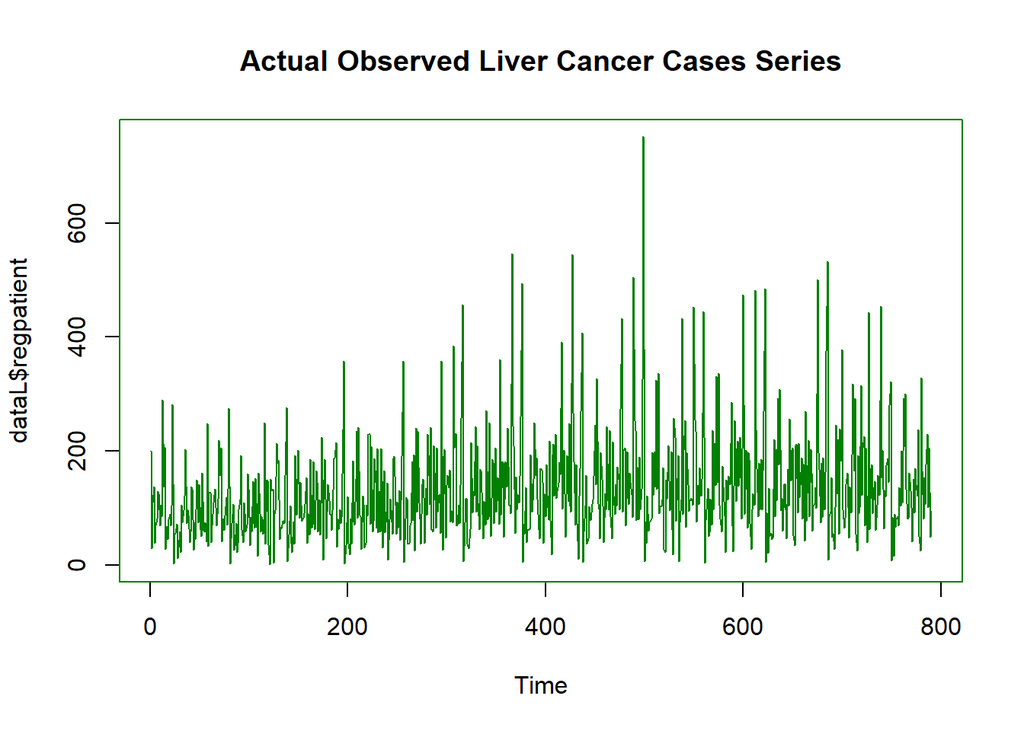

```r
par(col = "#008000")
plot.ts(dataL$regpatient, main = "Actual Observed Liver Cancer Cases Series")
```

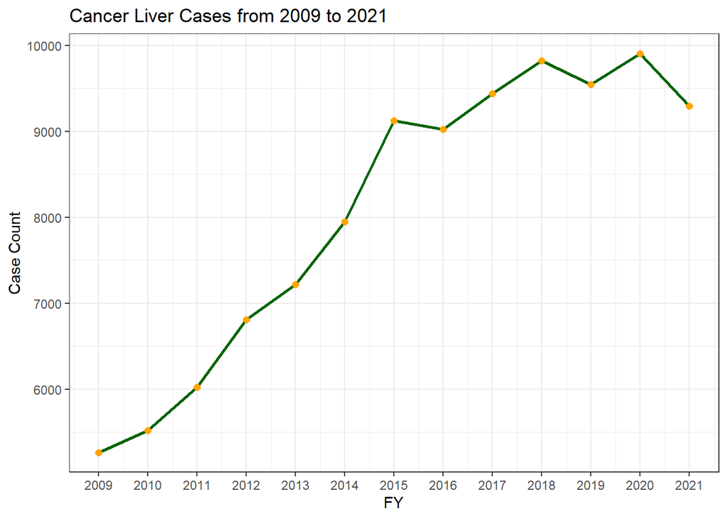

```r
# cases count by year
plt <- dataByFY %>%
  ggplot(aes(x = fy, y = regpatient)) +
  geom_line(color = "darkgreen", lwd = 1) +
  geom_point(color = "orange", lwd = 2) +
  theme_bw() +
  ggtitle("Cancer Liver Cases from 2009 to 2021") +
  xlab("FY") +
  ylab("Case Count") +
  scale_x_continuous(breaks = 2009:2021)
```

The number of liver cancer cases progressively increased over the years, except there are dips in 2016, 2019, and 2021. The table below shows the overview of the number of cases, average count, and percentage of case changes from year to year:

Liver Cancer Cases Overview

| fy | case_count | avg_count | percent_change |
| --- | --- | --- | --- |
| 2009 | 5267 | 92.4 | NA |
| 2010 | 5524 | 95.2 | 4.9 |
| 2011 | 6026 | 103.9 | 9.1 |
| 2012 | 6809 | 113.5 | 13.0 |
| 2013 | 7223 | 118.4 | 6.1 |
| 2014 | 7948 | 134.7 | 10.0 |
| 2015 | 9124 | 147.2 | 14.8 |
| 2016 | 9023 | 147.9 | -1.1 |
| 2017 | 9443 | 154.8 | 4.7 |
| 2018 | 9821 | 158.4 | 4.0 |
| 2019 | 9549 | 151.6 | -2.8 |
| 2020 | 9908 | 154.8 | 3.8 |
| 2021 | 9297 | 145.3 | -6.2 |

# 2. Decompose the Data

Using decompose () function from base R to visually examine trends and patterns including seasonality in the data in four individual O, T, S, and R components:

- The first graph is the **O**bserved data,
- the second is the **T**rend which is the moving average (MA),
- the third is **S**easonal signals without the irregular fluctuations involved, and
- the last graph is the **R**andom signals those are general fluctuations in the data that cannot be accounted for.

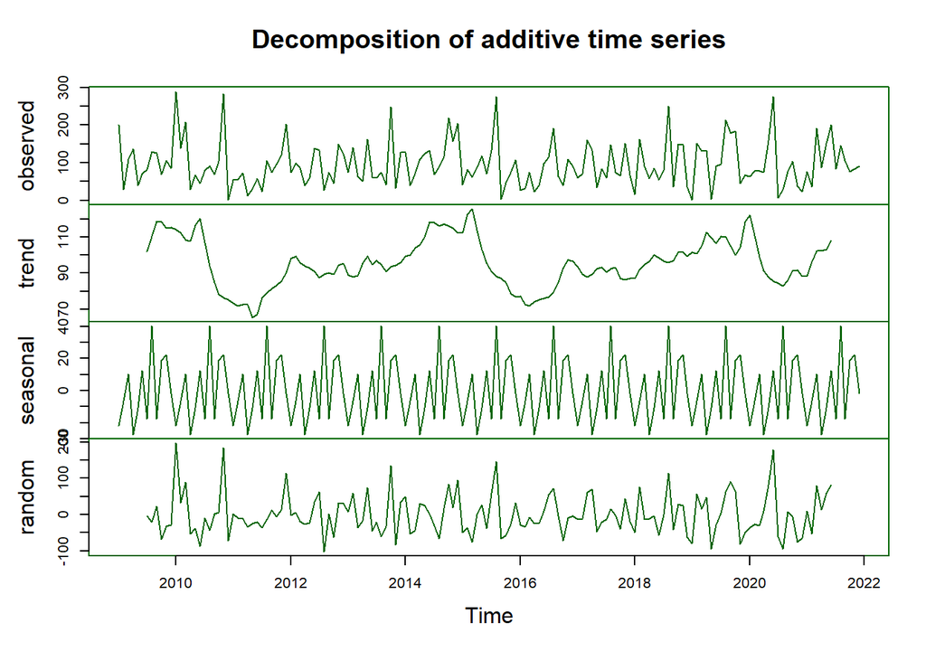

```r
# convert data into time series object
dataL.ts <- (ts(dataL$regpatient, start = c(2009, 1), end = c(2021, 12), freq = 12))
# decompose data
par(col = "darkgreen")
decomp_add <- decompose(dataL.ts, type = "additive")
plot(decomp_add)
```

# 3. Check Data for Stationary

Stationarity is an important concept in the field of time series (TS) analysis with tremendous influence on how the data is perceived and predicted. When forecasting or predicting the future, each point is independent of one another in most TS models. The augmented dickey fuller (ADF) test is a common test in statistics and is used to check whether a given TS is stationary or at rest if it doesn’t have any trend and depicts a constant variance over time and follows autocorrelation structure over a period constantly. The more negative magnitude of the ADF number is, the stronger the rejection of the hypothesis that there is a unit root at some level of confidence.

```r
adf.test(dataL.ts)
```

```
##
##  Augmented Dickey-Fuller Test
##
## data:  dataL.ts
## Dickey-Fuller = -5.9906, Lag order = 5, p-value = 0.01
## alternative hypothesis: stationary
```

Dickey-Fuller returns negative value confirms that TS is stationary. In addition, the p-value is less than 0.05 is typically considered to be statistically significant, in which case the null hypothesis should be rejected, concluded that this TS is stationary. The data series is ready to be analyzed.

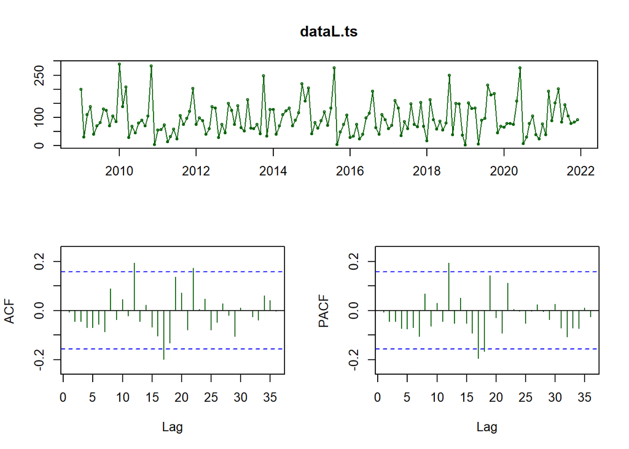

```r
forecast::tsdisplay(dataL.ts, col = "darkgreen")
```

The ACF plots the correlation coefficient against the lag, which is measured in terms of a number of periods or units. The blue dashed lines represent an approximate confidence interval (CI) for what is produced by white noise, by default the lines are displaying the 95 CI. Anything displays above the blue line is notably strong; anything displays below is not distinguishable from zero.

If we have strong peeks that means we definitely have autocorrelation structure in our data. From visual assessment, our time plots do not show trends or seasonality which is considered stationary.